# Final Project

*Group member:* Xiang Li, Ruilin Zhang, Boshen Qiu

# INTRODUCTION

Data science is a “concept to unify statistics, data analysis, machine learning and their related methods” in order to “understand and analyze actual phenomena” with data (*WIKIPEDIA*). In simple terms, data science is defined as gather data from the real world, parse the data into machine formats, use the machine to find patterns and trends, use the findings to build model make predictions and forecastings, and lastly, apply to the model to real world. These five steps in data science are also known as data science pipeline and can be abbreviated as Obtain, Scrub, Explore, Model, Interpret (OSEMN).

### Data Science Pipleline

[figure not shown]

This tutorial will walk through the awesome (OSEMN) steps of data science pipeline using a dataset on *Kaggle*.

Here is the link to the [dataset](https://www.kaggle.com/russellyates88/suicide-rates-overview-1985-to-2016).

# Step 1: Obtain

The dataset on suicide rate from 1985 ro 2016 can be find on [Kaggle](https://www.kaggle.com/). There are other data repositories, such as [data.world](https://data.world/), [data.gov](https://www.data.gov/), [Gapminder](https://www.gapminder.org/data/).

You can also scrape data from various sources, for example, web pages, emails, documents, and convert the data into csv files. However, we will not cover data extraction in this tutorial.

# Step 2: Srub

### QESTION 1: What are CSV files?

CSV stands for **Comma-Separated Values**. A CSV file stores tabular data in plain text. Each line of the file is a data record. Each record consists of one or more fields, separated by commas (*WIKIPEDIA*). It is a common data exchange format that is widely supported by different scientific operations including R and Python.

In this tutorial, we will use R to perform data management, exploratory data analyis, hypothesis testing and machine learning. For more imformation about how ingestion of CSV files work, click [here](http://www.hcbravo.org/IntroDataSci/bookdown-notes/ingesting-data.html#structured-ingestion)

### QUESTION 2: How do I load CSV files into R?

To load our dataset, *master.csv*, we need the *read_csv* function in *tidyverse* package. To include the *tidyverse* package, we use the command `library(tidyverse)`. To load our dataset, we use the command `read_csv("master.csv")`. Note that this csv file contains more than 20 thousand rows, so we use `head()` to display the first 6 rows.

```r
library(tidyverse)
head(read_csv("master.csv", col_types = cols()))
```

```
## # A tibble: 6 x 12
##   country  year sex   age   suicides_no population `suicides/100k ~
##   <chr>   <dbl> <chr> <chr>       <dbl>      <dbl>            <dbl>
## 1 Albania  1987 male  15-2~          21     312900             6.71
## 2 Albania  1987 male  35-5~          16     308000             5.19
## 3 Albania  1987 fema~ 15-2~          14     289700             4.83
## 4 Albania  1987 male  75+ ~           1      21800             4.59
## 5 Albania  1987 male  25-3~           9     274300             3.28
## 6 Albania  1987 fema~ 75+ ~           1      35600             2.81
## # ... with 5 more variables: `country-year` <chr>, `HDI for year` <dbl>,
## #   `gdp_for_year ($)` <dbl>, `gdp_per_capita ($)` <dbl>, generation <chr>
```

# Step 3: Explore

Let’s first take a look at the original data.

```r
db <- read_csv("master.csv")
```

Note that the columns country, sex, age, country-year, genration are parsed into character values, and the rest are parsed into numerical values. There are 12 columns in this table, and each column is an *attribute*. Each column can contain different types of values, but the values within the same column should be the same type.

We also want to know how many row our table has. We can use `nrow(db)` to find out.

```r
nrow(db)
```

```
## [1] 27820
```

It contains 27820 rows, and each row is an *entity*.

### Visualize the entire dataset

At the very beginning, we would like to show you how the dataset we chose look like, so you will get a chance to see the entire structure of the dataset, and get a sense of what our dataset is about, and what information it contains.

We can visualize the dataset in a clear way by applying the function `datatable(head(db), style="bootstrap", class="table-condensed", options = list(dom = 'tp',scrollX = TRUE))`

This function creates an HTML widget to display rectangular data (a matrix or data frame) using the JavaScript library DataTables.

By using this function, we can easily put the dataset into a data table. The function automatically provide functions such as order by column.

For more information about the function `datatable`, go the the website [Rdocumentation_datatable](https://www.rdocumentation.org/packages/DT/versions/0.5/topics/datatable).

```r
datatable(head(db), style="bootstrap", class="table-condensed", options = list(dom = 'tp',scrollX = TRUE))
```

|  | country | year | sex | age | suicides_no | population | suicides/100k pop | country-year | HDI for year | gdp_for_year ($) | gdp_per_capita ($) | generation |
| --- | --- | --- | --- | --- | --- | --- | --- | --- | --- | --- | --- | --- |
| 1 | Albania | 1987 | male | 15-24 years | 21 | 312900 | 6.71 | Albania1987 |  | 2156624900 | 796 | Generation X |
| 2 | Albania | 1987 | male | 35-54 years | 16 | 308000 | 5.19 | Albania1987 |  | 2156624900 | 796 | Silent |
| 3 | Albania | 1987 | female | 15-24 years | 14 | 289700 | 4.83 | Albania1987 |  | 2156624900 | 796 | Generation X |
| 4 | Albania | 1987 | male | 75+ years | 1 | 21800 | 4.59 | Albania1987 |  | 2156624900 | 796 | G.I. Generation |
| 5 | Albania | 1987 | male | 25-34 years | 9 | 274300 | 3.28 | Albania1987 |  | 2156624900 | 796 | Boomers |
| 6 | Albania | 1987 | female | 75+ years | 1 | 35600 | 2.81 | Albania1987 |  | 2156624900 | 796 | G.I. Generation |

### Getting data needed

In this dataset, we can see that there are 27820 rows. How can we see just one of them. Let’s take a look at the first row. We can select a row from a table by its index using `slice(db, c(1))`.

```r
slice(db, c(1))
```

```
## # A tibble: 1 x 12
##   country  year sex   age   suicides_no population `suicides/100k ~
##   <chr>   <dbl> <chr> <chr>       <dbl>      <dbl>            <dbl>
## 1 Albania  1987 male  15-2~          21     312900             6.71
## # ... with 5 more variables: `country-year` <chr>, `HDI for year` <dbl>,
## #   `gdp_for_year ($)` <dbl>, `gdp_per_capita ($)` <dbl>, generation <chr>
```

If we want to see the values on the nth column, we can use the funciton `select(db, n)`. Let’s select the first column.

```r
head(select(db,c(1)))
```

```
## # A tibble: 6 x 1
##   country
##   <chr>
## 1 Albania
## 2 Albania
## 3 Albania
## 4 Albania
## 5 Albania
## 6 Albania
```

The first column contains too many values, to save space, we only display the first six. If we want to we all the different values of the attribute *country*, we can use the command `unique(db$country)`.

```r
unique(db$country)
```

```
##   [1] "Albania"                      "Antigua and Barbuda"
##   [3] "Argentina"                    "Armenia"
##   [5] "Aruba"                        "Australia"
##   [7] "Austria"                      "Azerbaijan"
##   [9] "Bahamas"                      "Bahrain"
##  [11] "Barbados"                     "Belarus"
##  [13] "Belgium"                      "Belize"
##  [15] "Bosnia and Herzegovina"       "Brazil"
##  [17] "Bulgaria"                     "Cabo Verde"
##  [19] "Canada"                       "Chile"
##  [21] "Colombia"                     "Costa Rica"
##  [23] "Croatia"                      "Cuba"
##  [25] "Cyprus"                       "Czech Republic"
##  [27] "Denmark"                      "Dominica"
##  [29] "Ecuador"                      "El Salvador"
```

[output cut: 36 more lines]

Observe that `db` holds all the data from the csv file, and it is called a **data frame**. To access a column in a data frame we use dollar sign followed by the name of the column. In our example, it is `$country`. Additionally, when we use the dollar sign ($), the column is extracted as a *vector*.

Moreover, in `slice()` and `select()` functions, c() means to creat a vector of the values insize, if we want to see more index, we can put them in the vector and the R will automatically show all of those results.

Example of selecting more than 1 rows:

```r
slice(db, c(1,4,50))
```

```
## # A tibble: 3 x 12
##   country  year sex   age   suicides_no population `suicides/100k ~
##   <chr>   <dbl> <chr> <chr>       <dbl>      <dbl>            <dbl>
## 1 Albania  1987 male  15-2~          21     312900             6.71
## 2 Albania  1987 male  75+ ~           1      21800             4.59
## 3 Albania  1993 male  55-7~           7     165000             4.24
## # ... with 5 more variables: `country-year` <chr>, `HDI for year` <dbl>,
## #   `gdp_for_year ($)` <dbl>, `gdp_per_capita ($)` <dbl>, generation <chr>
```

When doing data analysis, it is very likely that we will apply some constraints for the data, such as we only want the data from the year 1987.

The function `filter()` can help us take out the data we need, and filter out those unnecessary/unrelated data.

In R, we use `==`, `!=`, `>`, `<` to make comparisons. When we want to check if the year is equal to 1987, we can use `year == 1987`.

```r
filter(db, year == 1987)
```

```
## # A tibble: 648 x 12
##    country  year sex   age   suicides_no population `suicides/100k ~
##    <chr>   <dbl> <chr> <chr>       <dbl>      <dbl>            <dbl>
##  1 Albania  1987 male  15-2~          21     312900             6.71
##  2 Albania  1987 male  35-5~          16     308000             5.19
##  3 Albania  1987 fema~ 15-2~          14     289700             4.83
##  4 Albania  1987 male  75+ ~           1      21800             4.59
##  5 Albania  1987 male  25-3~           9     274300             3.28
##  6 Albania  1987 fema~ 75+ ~           1      35600             2.81
##  7 Albania  1987 fema~ 35-5~           6     278800             2.15
##  8 Albania  1987 fema~ 25-3~           4     257200             1.56
##  9 Albania  1987 male  55-7~           1     137500             0.73
## 10 Albania  1987 fema~ 5-14~           0     311000             0
## # ... with 638 more rows, and 5 more variables: `country-year` <chr>, `HDI
## #   for year` <dbl>, `gdp_for_year ($)` <dbl>, `gdp_per_capita ($)` <dbl>,
## #   generation <chr>
```

### Pipelines of operations

When using R, one of the most important tool you should know and be familiar with is the `pipeline`.

The functions implementing our first set of operations have the same argument/value structure. They take a data frame as a first argument and return a data frame. We refer to this as the **data->transform->data** pattern. This is the core a lot of what we will do in class as part of data analyses. Specifically, we will combine operation into *pipelines* that manipulate data frames.

The `dplyr` package introduces syntactic sugar to make this pattern explicit. For instance, we can rewrite our previous example using the ??pipe?? operator `%>%`

```r
db %>%
  slice(c(1))
```

```
## # A tibble: 1 x 12
##   country  year sex   age   suicides_no population `suicides/100k ~
##   <chr>   <dbl> <chr> <chr>       <dbl>      <dbl>            <dbl>
## 1 Albania  1987 male  15-2~          21     312900             6.71
## # ... with 5 more variables: `country-year` <chr>, `HDI for year` <dbl>,
## #   `gdp_for_year ($)` <dbl>, `gdp_per_capita ($)` <dbl>, generation <chr>
```

**IMPORTANT!** The `%>%` binary operator takes the value to its **left** and inserts it as the first argument of the function call to its **right**. So the expression `LHS %>% f(another_argument)` is equivalent to the expression `f(LHS, another_argument)`.

By using `%>%`, We can combine several steps together.

```r
db %>%
  filter(year == 1987) %>%
  slice(c(1))
```

```
## # A tibble: 1 x 12
##   country  year sex   age   suicides_no population `suicides/100k ~
##   <chr>   <dbl> <chr> <chr>       <dbl>      <dbl>            <dbl>
## 1 Albania  1987 male  15-2~          21     312900             6.71
## # ... with 5 more variables: `country-year` <chr>, `HDI for year` <dbl>,
## #   `gdp_for_year ($)` <dbl>, `gdp_per_capita ($)` <dbl>, generation <chr>
```

Here, we first select the data for year 1987, then we slice the first row of that dataset.

### Create new attributes.

When dealing with the current dataset, it is common for data scientist to add more necessary attributues based on the current dataset to make it more readable.

Adding more attributes is similar to adding more columns in the data table. The function `mutate` creates new attributes based on the result of a given expression.

```r
db %>%
  mutate(ratio = suicides_no / population)
```

```
## # A tibble: 27,820 x 13
##    country  year sex   age   suicides_no population `suicides/100k ~
##    <chr>   <dbl> <chr> <chr>       <dbl>      <dbl>            <dbl>
##  1 Albania  1987 male  15-2~          21     312900             6.71
##  2 Albania  1987 male  35-5~          16     308000             5.19
##  3 Albania  1987 fema~ 15-2~          14     289700             4.83
##  4 Albania  1987 male  75+ ~           1      21800             4.59
##  5 Albania  1987 male  25-3~           9     274300             3.28
##  6 Albania  1987 fema~ 75+ ~           1      35600             2.81
##  7 Albania  1987 fema~ 35-5~           6     278800             2.15
##  8 Albania  1987 fema~ 25-3~           4     257200             1.56
##  9 Albania  1987 male  55-7~           1     137500             0.73
## 10 Albania  1987 fema~ 5-14~           0     311000             0
## # ... with 27,810 more rows, and 6 more variables: `country-year` <chr>,
## #   `HDI for year` <dbl>, `gdp_for_year ($)` <dbl>, `gdp_per_capita
## #   ($)` <dbl>, generation <chr>, ratio <dbl>
```

### Summarize attribute values over entities

Once we have a set of entities and attributes in a given data frame, we may need to summarize attribute values over the set of entities in the data frame. It collapses the data frame to a single row containing the desired attribute summaries. Such as finding the sum, min, average.

Continuing with the example we used, we may want to know what the minmum, maximum and average suicides_no in the dataset is:

```r
summarize(db, min_no=min(suicides_no), mean_no=mean(suicides_no), max_no=max(suicides_no))
```

```
## # A tibble: 1 x 3
##   min_no mean_no max_no
##    <dbl>   <dbl>  <dbl>
## 1      0    243.  22338
```

`Mean`, `Median`, `sd`, `min`, `max`, `n`, `n_distinct`, `any`, `all`, all of these are summarize functions you can use when trying to analyze your dataset.

### Group entities

Remember that **`group_by` function is usually followed by a `summarize` functions**.

```r
db %>%
  group_by(year) %>%
  summarize(total_suicide = sum(suicides_no))
```

```
## # A tibble: 32 x 2
##     year total_suicide
##    <dbl>         <dbl>
##  1  1985        116063
##  2  1986        120670
##  3  1987        126842
##  4  1988        121026
##  5  1989        160244
##  6  1990        193361
##  7  1991        198020
##  8  1992        211473
##  9  1993        221565
## 10  1994        232063
## # ... with 22 more rows
```

This function will calculate the total amount of suicide number for each year individually.

### Plotting with ggplot

Plotting serves many important roles in data analysis. We use it to gain understanding of dataset characteristics throughout analyses and it is a key element of communicating insights we have derived from data analyses with our target audience.

The `ggplot` package is designed to work well with the `tidyverse` set of packages. As such, it is designed around the Entity-Attribute data model. Also, it can be included as part of data frame operation pipelines.

For more information about `ggplot`, go to the website ggplot

There are several frequently used plot in R

- Scatter Plot
- Bar Chart
- Histogram
- Boxplot

Since we want to investigate what factors are correlated to the number of suicides, we can make plots that demonstrate the relationship between the number of suicides and other factors.

We can investigate the relationship between no. of suicides and country by creating a scatter plot.

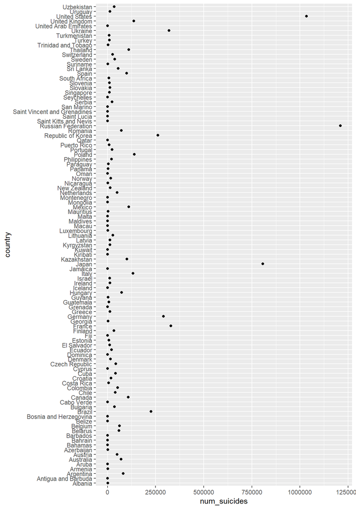

```r
db %>%
  group_by(country) %>%
  summarize(num_suicides= sum(suicides_no)) %>%
  ggplot(mapping=aes(y=country, x=num_suicides)) +
    geom_point()
```

The central design for `ggplot` is very elegant, the central premise is to characterize the building pieces behind ggplot plots as follows:

- The **data** that goes into a plot, a data frame of entities and attributes
- The **mapping** between data attributes and graphical (aesthetic) characteristics
- The **geometric representation** of these graphical characteristics

In general, the `ggplot` call will have the following structure: `<data_frame> %>% ggplot(mapping=aes(<graphical_characteristic>=<attribute>)) + geom_<representation>()`

#### Bar Graph

Used to visualize the relationship between a continuous variable to a categorical (or discrete) attribute

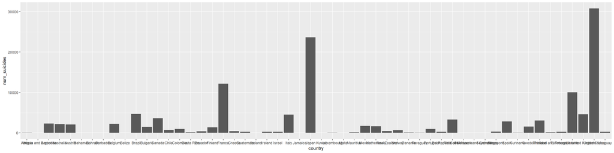

```r
db %>%
  filter(year == 1987) %>%
  group_by(country) %>%
  summarize(num_suicides= sum(suicides_no)) %>%
  ggplot(mapping=aes(x=country, y=num_suicides)) +
    geom_bar(stat="identity")
```

#### Histogram

Used to visualize the distribution of the values of a numeric attribute

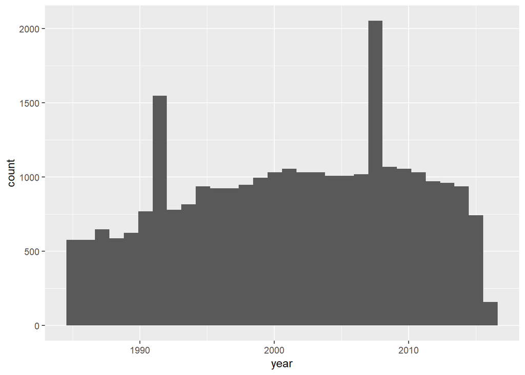

```r
db %>%
  ggplot(mapping=aes(x=year)) +
    geom_histogram()
```

Because we have too much x values stored, you can see that the histogram are all gathered together, and it’s very hard to distinguish them. So we can either change the binwidth of the graph, or decrease the amount of x values. We can do it by add a filter before we draw the graph. Such as

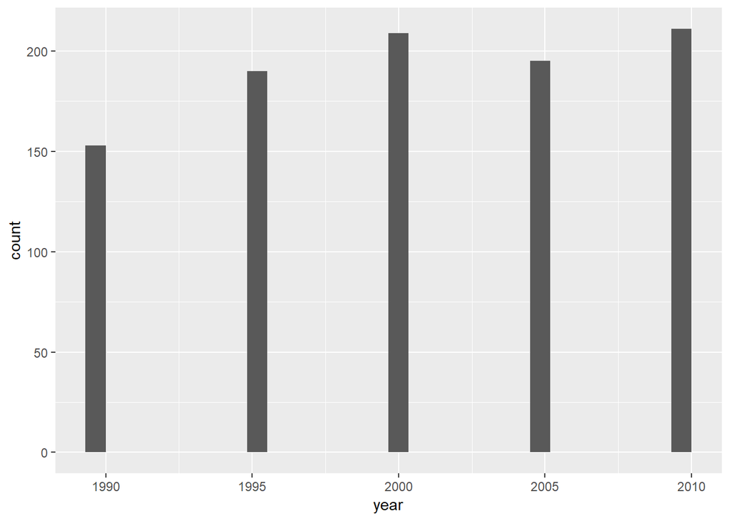

```r
db %>%
  filter(year == c(1990,1995,2000,2005,2010)) %>%
  ggplot(mapping=aes(x=year)) +
    geom_histogram()
```

#### Boxplot

Used to visualize the distribution of a numeric attribute based on a categorical attribute

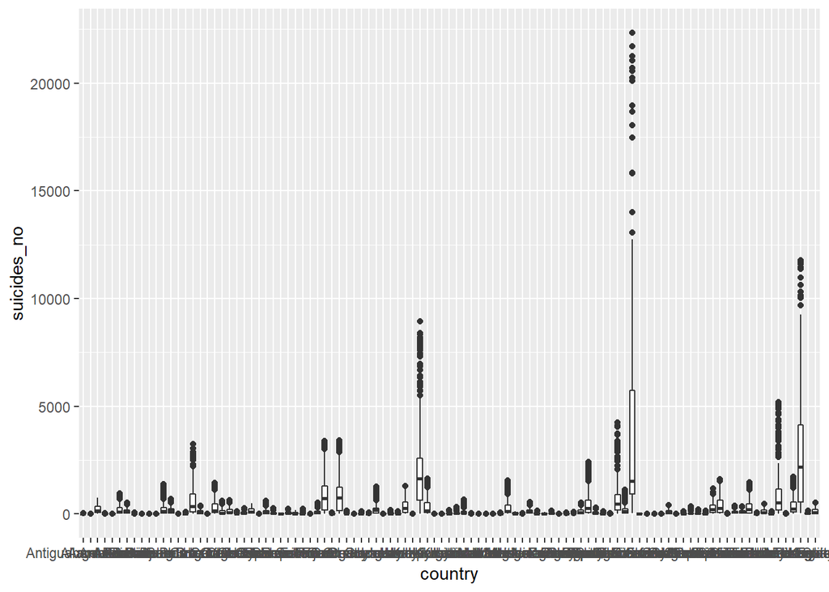

```r
db %>%
  ggplot(mapping=aes(x=country, y=suicides_no)) +
    geom_boxplot()
```

Similar to the Histogram problem, we can see that there are too much values in the graph which make it hard to visualize. We can do the similar things by adding a filter at the beinning.

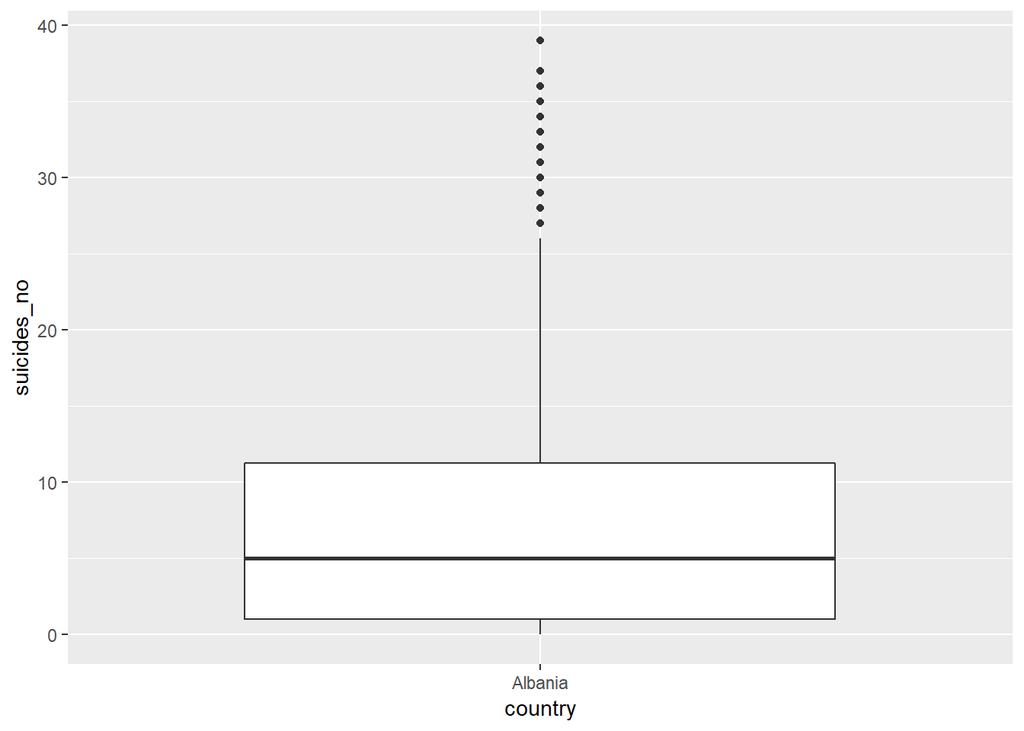

```r
db %>%
  filter(country == "Albania")%>%
  ggplot(mapping=aes(x=country, y=suicides_no)) +
    geom_boxplot()
```

We can also manage the height and width of the output plot by adding instructions on ````{r}`

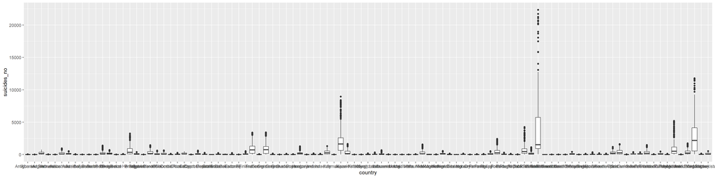

```r
db %>%
  ggplot(mapping=aes(x=country, y=suicides_no)) +
    geom_boxplot()
```

### The Entity-Relationship and Relational Models

The fundamental objects in this formalism are *entities* and their *attributes*, as we have seen before, and *relationships* and *relationship attributes*. Entities are objects represented in a dataset: people, places, things, etc. Relationships model just that, relationships between entities.

For more information about Entity_Relationship and Relational Models, check [here](https://www.webopedia.com/TERM/E/entity_relationship_diagram.html)

### Tidy Data

Tidy Data refers to datasets that are represented in a form that is amenable for manipulation and statistical modeling.

We want to prepare and organize our data in a way that is amenable for analysis, both in modeling and visualization. We think of a data model as a collection of concepts that describes how data is represented and accessed.

Here we assume we are working in the [ER data model](https://github.com/umddb/datascience-fall14/blob/master/lecture-notes/models.md) represented as **relations**: rectangular data structures where

- Each attribute (or variable) forms a column
- Each entity (or observation) forms a row
- Each type of entity (observational unit) forms a table

There are several common problems in messy data (in our example, we have *multiple variables stored in one column*)

- Column headers are values, not variable names (gather)
- Multiple variables stored in one column (split)
- Variables stored in both rows and column (rotate)
- Multiple types of observational units are stored in the same table (normalize)
- Single observational unit stored in multiple tables (join)

In our previous example,

```r
slice(db,c(1))
```

```
## # A tibble: 1 x 12
##   country  year sex   age   suicides_no population `suicides/100k ~
##   <chr>   <dbl> <chr> <chr>       <dbl>      <dbl>            <dbl>
## 1 Albania  1987 male  15-2~          21     312900             6.71
## # ... with 5 more variables: `country-year` <chr>, `HDI for year` <dbl>,
## #   `gdp_for_year ($)` <dbl>, `gdp_per_capita ($)` <dbl>, generation <chr>
```

We can see that there is one column(attribute) specifically designed to store *country-year*. This is a combination of more than 1 attributes. But there are already two separated columns to sotre *year* and *country*. It’s a duplicate of attributes, and it does not follow the rule of ER relationship. To make this dataset tidy, instead of split, we can **delete** the *country-year* attribute.

```r
db <- db[,-8]
```

For more information about deleting attributes, go to [drop data frame columns by name](https://stackoverflow.com/questions/4605206/drop-data-frame-columns-by-name)

### Handling Missing Data

By missing data we mean values that are unrecorded, unknown or unspecified in a dataset.

Data that is missing systematically can significantly bias an analysis. For example: Suppose we want to predict how sick someone is from test result. If doctors do not carry out the test because a patient is too sick, then the fact test is missing is a great predictor of how sick the patient is.

So in general, the first step when dealing with missing data is to understand why and how data may be missing. I.e., talk to collaborator, or person who created the dataset. Once you know that data is not missing systematically and a relatively small fraction of observations contain have missing values, then it may be safe to remove observations.

There are few major ways of dealing missing data

- Encoding as missing (In the case of categorical attributes, a useful approach is to encode the fact that a value is missing as a **new category** and include that in subsequent modeling.)
- Imputation (In the case of numeric values, we can use a simple method for imputation where we replace missing values for a variable with, for instance, the **mean** of non-missing values)

# Step 4: Model

Data representational modeling is the process of representing/capturing structure in data based on defining:

- **Data model**: A collection of concepts that describes how data is represented and accessed
- **Schema**: A description of a specific collection of data, using a given data model

The purpose of defining abstract data representation models is that it allows us to know the structure of the data/information (to some extent) and thus be able to write general purpose code. Lack of a data model makes it difficult to share data across programs, organizations, systems that need to be able to integrate information from multiple sources.

A data model typically consists of:

- Modeling Constructs: A collection of concepts used to represent the structure in the data. Typically we need to represent types of *entities*, their *attributes*, types of *relationships* between entities, and relationship attributes
- Integrity Constraints: Constraints to ensure data integrity (i.e., avoid errors)
- Manipulation Languages: Constructs for manipulating the data

### Regression Analysis

Regression analysis is a reliable method of identifying which atrributes have impact on our variable of interest, number of suicides.

#### Simple Linear Regression

First let’s begin with a generalized linear relationship formula :
$$y = \beta_0 + \beta_1\cdot x$$
where
$$\beta_0 = intercept, \beta_1=slope$$
y is the number of suicides, and x is the independent variable. In this example, we assume there is a linear relationship between the y values and the x values.

Let’s first choose *population* as our independent variable.

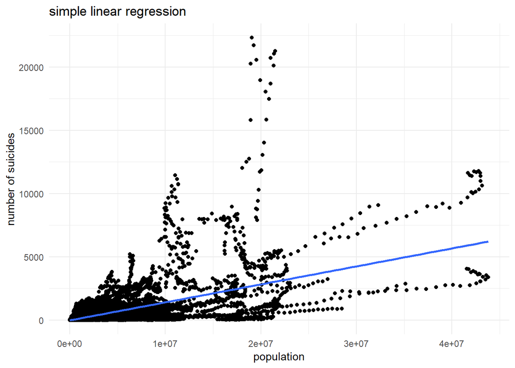

```r
db %>%
  ggplot(aes(x=population, y=suicides_no)) +
    geom_point() +
    geom_smooth(method=lm) +
    theme_minimal() +
    labs(title = "simple linear regression", x = "population", y = "number of suicides")
```

The blue line is called the regression line. The method of least squares is commonly used to find the regression line. Least squares minimizes the sum of squared residuals, where residual is the vertical distance from each data points to the regression line.

In R, linear models are built using the `lm()` function.

```r
lm(suicides_no~population, data=db)
```

```
##
## Call:
## lm(formula = suicides_no ~ population, data = db)
##
## Coefficients:
## (Intercept)   population
##  -1.954e+01    1.421e-04
```

Recall our formula:
$$y = \beta_0 + \beta_1\cdot x$$
In this example,
$$\beta_0=Intercept=-1.954e+01, \beta_1=population=1.421e-04$$
Now for different population size, we can predict the number of suicides in this population. Here you might want to ask, is there truely a relationship between these two variables? We will use hypothesis tests in statistics.

A statistical hypothesis, is a claim or assertion either about the value of a single parameter (population characteristic or characteristic of a probability distribution), about the values of several parameters, or about the form of an entire probability distribution. In our example, we want to test the value of beta_1.

In any hypothesis-testing problem, there are two contradictory hypotheses under consideration. The null hypothesis, denoted by H_0, is the claim that is initially assumed to be true (the “prior belief” claim). The alternative hypothesis, denoted by H_a, is the assertion that is contradictory to H_0. In our example, our null hypothesis is that there **is no** significant relationship between number of suicides and population sizes, which can be expressed as
$$\beta_1=0$$
Our alternative hypothesis is that there **is** significant relationship between number of suicides and population sizes, which can be expressed as
$$\beta_1\neq0$$

To perform hypothesis tests, we use the following R code:

```r
suicide_fit <- lm(suicides_no~population, data=db)
suicide_fit %>%
  tidy() %>%
  select(term, estimate, statistic, p.value)
```

```
## # A tibble: 2 x 4
##   term          estimate statistic   p.value
##   <chr>            <dbl>     <dbl>     <dbl>
## 1 (Intercept) -19.5          -4.15 0.0000334
## 2 population    0.000142    130.   0
```

A test statistic is a function of the sample data used as a basis for deciding whether H_0 should be rejected (Jay L. Devore).

The p.value is the probaility, calculated assuming the the null hypothesis is true, of obtaining a value of the statistic at least as contradictory to H_0 as the value calculated from the available sample data (Jay L. Devore).

Before reaching to a conlusion, we need to choose a significance level that is reasonably close to 0. The null hypothesis will be rejected and alternative hypothesis will be favored if p.value is smaller than or equal to our significance level. Otherwize, the null hypothesis will not be rejected. The significance levels used most frequently in practice are 0.5, 0.1, 0.05, 0.01, and 0.001.

From now on, we will fix our significance level at 0.01. Obeserve the our p.value is smaller than our significance level, thus we should favor the alternative hypothesis, that is,
$$\beta_1\neq0$$

#### Dummy Variables

Note that in our previous example, population is a numerical variable and it can be directly put into the regression fomula. What if we want to use a catagorical variable to predict the number of suicides? We can create dummy variables.

```r
temp <- db %>%
  mutate(numerical_sex=ifelse(sex=="female", 1, 0)) %>%
  select(suicides_no, numerical_sex)
head(temp)
```

```
## # A tibble: 6 x 2
##   suicides_no numerical_sex
##         <dbl>         <dbl>
## 1          21             0
## 2          16             0
## 3          14             1
## 4           1             0
## 5           9             0
## 6           1             1
```

Now we can use the new variable to predict number of suicides safely. You can follow the procedure mention above to find the regression line and it is left for you as an exercise.

#### Multiple Linear Regression

What if our dummy variable has more than two levels, such as country and age? We need more dummy variables. These means that we have to put more independent variables into our regression formula. In real world, a variable of interest always has more than 1 correlating independent variables, thus we need to update our simple formla for including more independent varialbes. Our generalized formla for multiple linear regression is
$$y=\beta_0+\beta_1\cdot x_1+\beta_2\cdot x_2+...+\beta_n\cdot x_n+$$
where n is the number of independent variables.

We will use sex, population size, and gdp to predict number of suicides.

```r
temp <- db %>%
  mutate(numerical_sex=ifelse(sex=="female", 1, 0)) %>%
  select(suicides_no, numerical_sex, population, `gdp_for_year ($)`)
suicide_fit <- lm(suicides_no~1+numerical_sex+population+`gdp_for_year ($)`, data=temp)
suicide_fit
```

```
##
## Call:
## lm(formula = suicides_no ~ 1 + numerical_sex + population + `gdp_for_year ($)`,
##     data = temp)
##
## Coefficients:
##        (Intercept)       numerical_sex          population
##          1.161e+02          -2.737e+02           1.455e-04
## `gdp_for_year ($)`
##         -1.131e-11
```

Is this model reliable?

```r
suicide_fit %>%
  tidy() %>%
  select(term, estimate, statistic, p.value)
```

```
## # A tibble: 4 x 4
##   term                estimate statistic   p.value
##   <chr>                  <dbl>     <dbl>     <dbl>
## 1 (Intercept)         1.16e+ 2     18.7  2.31e- 77
## 2 numerical_sex      -2.74e+ 2    -32.7  1.02e-230
## 3 population          1.45e- 4     95.8  0.
## 4 `gdp_for_year ($)` -1.13e-11     -2.77 5.66e-  3
```

We can see that the p.value for each independent variable is smaller than our significance level, 0.01, thus there is strong relationship between number of suicides and sex, population size, and gdp.

We can continue to add other variables into our regression analysis.

# Step 5: Interpret.

From the suicide dataset we can obtain a general understanding of the different factors that affect the number of suicides. We see that number of suicides varies in different country with different gpd, in different years, and in different groups of people (male or female), etc. However, we cannot answer questions like why are these factors related to the number of suicides. One dataset is no enough for us to gain deep insights into our problem.